# Final assignment

Veronica Capuccio

04 August 2017

## Descriptive statistics and cleaning data

```r
library(ggplot2)
library(caret)
library(corrplot)

#Set directory
rm(list=ls())
setwd("C:\\Users\\Veronica\\Desktop\\Coursera\\Machine learning\\week4")

#Load data
training<-read.csv("pml-training.csv", na.strings=c("","NA"))
testing<-read.csv("pml-testing.csv", na.strings=c("","NA"))
```

The response variable is a qualitative variable with 5 categories. There are 159 possible predictors.

I convert some factor variables in to numeric variables because they have been erroneously declared as factors but their nature is numeric. I excluded class, username, cvtd_timestamp and new_window(yes/no) variables.

```r
colfactor<-sapply(training, is.factor)
colfactor[c(2,5,6,160)]<-FALSE

training[colfactor]<-lapply(training[colfactor], function(x) as.numeric(as.character(x)))
training<-as.data.frame(training)
```

I calculate the percentage of missing value for each variable

```r
count<-apply(training, 2, function(x) sum(is.na(x)))
NApercentage<-(count/dim(training)[1]) * 100
table(NApercentage)
```

```
## NApercentage
##                0 97.9308938946081 97.9359902150647 97.9410865355214
##               60               67                1                1
## 97.9512791764346 97.9563754968912 97.9767607787178 97.9818570991744
##                1                4                1                4
##  97.986953419631 98.0939761492203 98.3233105697686 98.3284068902253
##                2                2                1                1
## 98.3385995311385 98.3538884925084  98.358984812965 98.3640811334217
##                2                1                4                2
##              100
##                6
```

```r
posdropvar<-which(NApercentage>97)
length(posdropvar)
```

```
## [1] 100
```

There are 100 predictors with a percentage of missing values > 97%. I remove the first 7 variables because they are user details and the features with missing values. I have 52 predictors.

```r
training2<-training[,-posdropvar]
training2<-training2[,-c(1:7)]
```

I create two partitions: 70% train and 30% test from original training data.

```r
set.seed(3523)
inTrain<-createDataPartition(y=training2$classe, p=0.7, list=F)
train<-training2[inTrain,]
test<-training2[-inTrain,]
```

## Linear discriminant analysis

```r
modlda<-train(classe~., data=train, method="lda")
pred<-predict(modlda, test)
confusionMatrix(pred, test$classe)$overall[1]
```

```
##  Accuracy
## 0.7016143
```

Linear discriminant analysis has an accuracy equal to 0.7016 on test set.

## Decision tree

I try to use a decision tree.

```r
modDT<-train(classe~.,data=train, method="rpart")
```

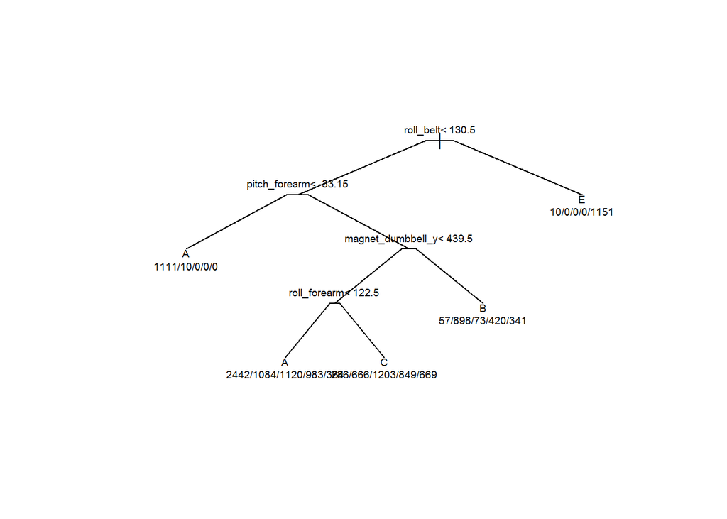

```r
plot(modDT$finalModel,margin=0.2,uniform=T,branch=0.1)
text(modDT$finalModel,use.n=T,cex=0.6)
```

```r
pred<-predict(modDT, test)
confusionMatrix(pred, test$classe)$overall[1] #0.4961
```

```
##  Accuracy
## 0.4961767
```

Decision tree has an accuracy equal to 0.4961. It is lower than lda method.

## Random forest

I try to adapt a random forest.

```r
fitControl <- trainControl(method = 'cv', number = 3)
modelRF <- train(classe ~.,data = train,
                  trControl = fitControl,method = 'rf',ntree = 100)
pred<-predict(modelRF, test)
confusionMatrix(pred, test$classe)$overall[1] #0.9918
```

```
##  Accuracy
## 0.9918437
```

## Prediction

The final model is modRF with accuracy equal to 0.9918 on test set.

I predict the 20 new observations on testing set:

```r
predict(modelRF, testing)
```

```
##  [1] B A B A A E D B A A B C B A E E A B B B
## Levels: A B C D E
```